# 25 Causal Discovery: Latent Variables

**Setup: packages and graph-plotting helpers**

```julia
using CausalInference
using RecursiveCausalDiscovery
using CausalGraphs
using Graphs
using CairoMakie
CairoMakie.activate!(type = "png")
using Statistics
using LinearAlgebra
using Random
using Printf
using DataFrames
using Combinatorics: powerset
using Distributions: Normal, quantile

# ── Graph helpers (shared with chapter 1) ────────────────────────────────────

function adjmat_to_admg(adj::AbstractMatrix, labels::Vector{String})
    n = size(adj, 1)
    vs = Symbol.(labels)
    di = [(vs[i], vs[j]) for i in 1:n, j in 1:n if adj[i,j] == 1]
    make_graph(vertices=vs, di_edges=di)
end

function skeleton_to_admg(g::SimpleGraph, labels::Vector{String})
    vs = Symbol.(labels)
    bi = [(vs[e.src], vs[e.dst]) for e in edges(g)]
    make_graph(vertices=vs, bi_edges=bi)
end

struct MultiSVG; html::String; end
Base.show(io::IO, ::MIME"text/html", m::MultiSVG) = print(io, m.html)

function side_by_side(graphs_titles; direction="TB", note="")
    items = String[]
    for (g, title) in graphs_titles
        svg = to_svg(g; direction=direction)
        svg === nothing && continue
        push!(items, """<div style="text-align:center;flex:1">
            <p style="margin:0 0 4px;font-weight:600">$title</p>$svg</div>""")
    end
    note_html = isempty(note) ? "" : """<p style="font-size:.85em;color:#666;margin-top:6px">$note</p>"""
    MultiSVG("""<div style="display:flex;gap:20px;flex-wrap:wrap;
        justify-content:center;align-items:flex-start">$(join(items))</div>$note_html""")
end

# Full DAG via CausalGraphs — latent nodes shown as squares (fixed=true), observed as plaintext
function admg_with_latent(adj::AbstractMatrix, all_labels, latent_idx)
    n = size(adj, 1)
    vs = Symbol.(all_labels)
    di = [(vs[i], vs[j]) for i in 1:n, j in 1:n if adj[i,j] == 1]
    g = make_graph(vertices=vs, di_edges=di)
    for i in latent_idx
        g.fixed[vs[i]] = true   # square shape marks hidden nodes
    end
    g
end
```

```julia
using CausalInference
using RecursiveCausalDiscovery
using CausalGraphs
using Graphs
using CairoMakie
CairoMakie.activate!(type = "png")
using Statistics
using LinearAlgebra
using Random
using Printf
using DataFrames
using Combinatorics: powerset
using Distributions: Normal, quantile
```

The previous chapter assumed all causally relevant variables were observed. That is a strong assumption. In economics, ability, demand shocks, and peer effects are often unobserved.

When latent confounders exist, PC and RSL-D can give the wrong graph. Here I use algorithms designed for latent variables.

### 25.0.1 Why PC fails with latent variables

Suppose the true graph is $X \leftarrow U \rightarrow Y$ where $U$ is unobserved. In the observed data, $X$ and $Y$ are marginally correlated (through $U$) and no observed conditioning set separates them. PC will incorrectly draw an edge $X - Y$ and may orient it as $X \to Y$ or $X \leftarrow Y$, neither of which exists in the truth.

With even one hidden common cause, the conditional independences among observed variables may not correspond to any DAG on the observed variables alone. We need a MAG/PAG representation.

## 25.1 Maximal Ancestral Graphs and PAGs

With latent variables, the appropriate representation is a **Maximal Ancestral Graph (MAG)**. Over a set of *observed* variables $\mathbf{O}$, a MAG encodes:

- $X \to Y$: $X$ is an ancestor of $Y$ in the full DAG
- $X \leftrightarrow Y$: $X$ and $Y$ have a common hidden ancestor (hidden confounder)
- No edge: $X \perp\!\!\!\perp Y \mid Z$ for some $Z \subseteq \mathbf{O} \setminus \{X, Y\}$

The MAG over observed variables summarizes the causal and confounding relationships visible in the observed data without naming the latent variables.

Just as DAGs have Markov equivalence classes represented by CPDAGs, MAGs have equivalence classes represented by **Partial Ancestral Graphs (PAGs)**. In a PAG, the mark $\circ$ on an edge endpoint means “could be arrowhead or tail in some member of the equivalence class.”

| PAG mark | Meaning | Economic interpretation |
| --- | --- | --- |
| $X \to Y$ | $X$ causes $Y$ in every equivalent MAG | Robust causal direction |
| $X \;\circ\!\!\!\to Y$ | Some MAGs have $X \to Y$, others $X \leftrightarrow Y$ (the arrowhead at $Y$ is invariant) | Direction uncertain |
| $X \leftrightarrow Y$ | Hidden common cause in every equivalent MAG | Definite unmeasured confounder |
| $X \;\circ\!\!\!\!-\!\!\!\!\circ\; Y$ | Could be $\to$, $\leftarrow$, or $\leftrightarrow$ | Maximally uncertain |

**Reading a PAG for policy purposes:**

- A definite $X \to Y$ edge is the most useful finding: it means any intervention on $X$ propagates to $Y$ regardless of which specific MAG the data came from.
- A definite $X \leftrightarrow Y$ edge is a warning: before using regression of $Y$ on $X$ to estimate a causal effect, you must address the hidden confounder — through an instrument, a proxy, or a natural experiment. A proxy here means proximal causal inference, which identifies the effect from two proxies of the hidden confounder, a negative-control exposure and a negative-control outcome (Miao, Geng, and Tchetgen Tchetgen 2018; Tchetgen Tchetgen et al. 2024); the [proximal chapter](https://xiangao.github.io/blog_book/proximal-intro.html) of *Topics on Econometrics and Causal Inference* introduces it.
- $\circ$ marks indicate what you *don’t* know. Additional data, temporal ordering, or experimental variation can resolve them.

## 25.2 Simulation with Hidden Variables

We reuse the same 8-node Gaussian linear DAG from the previous chapter and hide 2 nodes, treating them as unobserved confounders.

```julia
Random.seed!(2025)

n_vars    = 8
n_samples = 2000
edge_prob = 0.35
latent    = [3, 6]
obs_idx   = setdiff(1:n_vars, latent)
all_labels = ["X$i" for i in 1:n_vars]
obs_labels = ["X$(obs_idx[i])" for i in 1:length(obs_idx)]

adj_mat   = gen_er_dag_adj_mat(n_vars, edge_prob)
data_full = gen_gaussian_data(adj_mat, n_samples)
data_obs  = data_full[:, obs_idx]
n_obs     = length(obs_idx)

@printf "Total variables: %d   Hidden: %s   Observed: %d\n" n_vars latent n_obs
```

```
Total variables: 8   Hidden: [3, 6]   Observed: 6
```

### 25.2.1 True structure over observed variables

Two observed variables are adjacent in the MAG iff no subset of the *observed* variables d-separates them in the full DAG.

```julia
true_dag = SimpleDiGraph(adj_mat)

function true_mag_skeleton(dag, observed)
    p = length(observed)
    skel = SimpleGraph(p)
    for i in 1:(p-1), j in (i+1):p
        u, v = observed[i], observed[j]
        other_obs = setdiff(observed, [u, v])
        separated = any(dsep(dag, u, v, S) for S in powerset(other_obs))
        !separated && add_edge!(skel, i, j)
    end
    return skel
end

true_obs_skel = true_mag_skeleton(true_dag, obs_idx)
@printf "True MAG skeleton edges (over %d observed nodes): %d\n" n_obs ne(true_obs_skel)
```

```
True MAG skeleton edges (over 6 observed nodes): 5
```

```julia
side_by_side([
    (admg_with_latent(adj_mat, all_labels, latent), "Full DAG (square = hidden)"),
    (skeleton_to_admg(true_obs_skel, obs_labels),   "True MAG skeleton (observed)"),
]; note="Square nodes are unobserved (latent). Plaintext nodes are observed.")
```

Full DAG (square = hidden)

[figure not shown]

True MAG skeleton (observed)

[figure not shown]

Square nodes are unobserved (latent). Plaintext nodes are observed.

Figure 25.1: Full DAG (square nodes are hidden) and true MAG skeleton over observed variables. Skeleton edges include both direct paths and paths through hidden variables.

## 25.3 FCI Algorithm

FCI is the extension of PC for latent variables. It starts from a complete graph, removes edges with CI tests, and then uses orientation rules that can produce bidirected edges for hidden common causes.

**How FCI extends PC:**

1. **Phase 1 (skeleton):** Same as PC — remove edges via CI tests with growing conditioning sets.
2. **Phase 2 (initial orientation):** Mark all edge endpoints as $\circ$ (uncertain); orient unshielded colliders as in PC.
3. **Phase 3 (Possible-D-SEP pruning):** For each remaining edge $X - Y$, compute the **Possible-D-SEP** sets and run *additional* CI tests conditioning on their subsets, removing further edges. With latent variables, two non-adjacent observed nodes need not be separable by a subset of their neighbors — this stage is what makes FCI’s skeleton differ from PC’s, and it is the computationally expensive part. Colliders are then re-oriented on the pruned skeleton.
4. **Phase 4 (rule propagation):** Apply the 10 orientation rules (Zhang 2008) that propagate known marks without creating contradictions, including rules that can produce definite $\to$ and $\leftrightarrow$ edges. These rules perform no CI tests and are cheap.

The extra marks let FCI say what is known and what remains uncertain, but the output is harder to read than a DAG.

```julia
sig_level = 0.01

count_fci = Ref(0)
ci_fci = (x, y, S, d) -> begin
    count_fci[] += 1
    fisher_z(x, y, collect(Int, S), Matrix{Float64}(d), sig_level)
end

pag_fci  = fcialg(n_obs, ci_fci, data_obs)
skel_fci = SimpleGraph(pag_fci)

f1_fci = f1_score(true_obs_skel, skel_fci)
@printf "FCI:     skeleton F1 = %.3f   CI tests = %d\n" f1_fci count_fci[]
```

```
FCI:     skeleton F1 = 0.889   CI tests = 75
```

```julia
# No `println` here: plot_fci_graph_text prints the edge list as a side effect and
# returns nothing, so wrapping it in println() appends a literal "nothing" to the
# output -- which is what the rendered page used to show.
plot_fci_graph_text(pag_fci, ["X$(obs_idx[i])" for i in 1:n_obs])
```

```
X1<-X2   X1<-X7   X2o-oX5  X5o-oX7
```

Figure 25.2

**Note**

**Reading the FCI text output**

The text representation uses ASCII edge marks:

- `X1 --> X2`: definite cause — $X_1$ is an ancestor of $X_2$ in every equivalent MAG (not necessarily a *direct* effect: the path may run through latent mediators)
- `X1 <-> X2`: definite hidden common cause ($X_1 \leftrightarrow X_2$)
- `X1 o-> X2`: the $X_1$ endpoint is uncertain; $X_2$ endpoint is definitely an arrowhead
- `X1 o-o X2`: both endpoints uncertain; could be any of $\to$, $\leftarrow$, $\leftrightarrow$

In practice for economic research: focus first on `<->` edges — these flag definite confounding and tell you where IV or proxy strategies are needed. Then examine `-->` edges — these are causal claims that survive across all statistically equivalent structures.

**When FCI gives wrong answers:** FCI assumes the CI tests are perfectly accurate (no finite-sample error). In practice, with small $n$ or many variables, some false CI decisions propagate through the orientation rules. The skeleton quality (F1) is generally more reliable than the orientation quality.

## 25.4 L-MARVEL Algorithm

**L-MARVEL** (Latent Markov Boundary Variable Elimination; Mokhtarian et al. (2025)) extends the recursive MARVEL approach to handle latent confounders. Instead of exhaustive CI-test-based Markov boundary discovery, L-MARVEL uses a **Gaussian precision matrix** estimator:

$$\widehat{\text{Mb}}(X) = \left\{Y : \frac{|\hat P_{XY}|}{\sqrt{\hat P_{XX} \hat P_{YY}}} > \tau\right\} \tag{25.1}$$

where $\hat P = \hat\Sigma^{-1}$ is the precision matrix and $\tau$ is a threshold from the Fisher-Z distribution.

In a Gaussian linear model, a zero in the precision matrix means conditional independence given all other variables. L-MARVEL uses this fact to estimate Markov boundaries with fewer CI tests.

The removability criterion changes for the latent case (Theorem 32). Recall: $\text{Mb}(X)$ is the Markov boundary of $X$ — the minimal conditioning set that screens $X$ off from all other variables (estimated here via the precision matrix above rather than by exhaustive CI tests) — and $\text{Ne}(X)$ is the set of variables directly adjacent to $X$ in the current skeleton. Variable $X$ is removable iff for every $Y \in \text{Mb}(X)$ and $Z \in \text{Ne}(X) \setminus \{Y\}$, at least one of two conditions holds (Theorem 32 of Mokhtarian et al. 2025):

$$\underbrace{\exists\, W \subseteq \text{Mb}(X) \setminus \{Y,Z\}: Y \perp\!\!\!\perp Z \mid W}_{\text{Condition 1}} \quad\text{or}\quad \underbrace{\forall\, W \subseteq \text{Mb}(X) \setminus \{Y,Z\}: Y \not\perp\!\!\!\perp Z \mid W \cup \{X\}}_{\text{Condition 2}} \tag{25.2}$$

**Intuition for the two conditions:**

- **Condition 1**: some subset of the Markov boundary separates $Y$ and $Z$. This is not the RSL-D criterion of the previous chapter. RSL-D asks instead for dependence given the whole boundary plus $X$, a single test that is valid only under its diamond-free DAG assumption.
- **Condition 2**: $Y$ and $Z$ are dependent given every subset of the boundary once $X$ is added to it. This is a condition of Theorem 32, not a d-separation rule. It does not say that conditioning on $X$ removes hidden confounding.

Together, the two conditions ensure that removing $X$ does not destroy information about the latent structure connecting its neighbours.

```julia
count_lm = Ref(0)
ci_lm = (x, y, S, d) -> begin
    count_lm[] += 1
    fisher_z(x, y, collect(Int, S), Matrix{Float64}(d), sig_level)
end

lm_skel = l_marvel(data_obs, ci_lm)

f1_lm = f1_score(true_obs_skel, lm_skel)
@printf "L-MARVEL: skeleton F1 = %.3f   CI tests = %d\n" f1_lm count_lm[]
```

```
L-MARVEL: skeleton F1 = 1.000   CI tests = 14
```

**Note**

**L-MARVEL output: skeleton only**

Unlike FCI, L-MARVEL returns only the **skeleton** — undirected edges with no arrowhead or bidirected marks. This is a deliberate design choice: the recursive removal procedure identifies *adjacencies* efficiently but does not run the full PAG orientation phase.

This is still valuable. Knowing which pairs of variables are adjacent tells you which potential causal relationships to investigate further (with instruments, experiments, or domain knowledge). A missing edge means some observed conditioning set separates the two variables under the graph assumptions. It does not rule out a causal effect. In $X \to M \to Y$, $X$ and $Y$ are not adjacent and $X \perp\!\!\!\perp Y \mid M$, yet the total effect of $X$ on $Y$ runs through $M$. Before excluding a pair from a causal question, we must examine directed paths and identification.

If you need orientations as well as skeleton, run FCI. If you only need to screen out non-adjacent pairs (the most common use case in large-$p$ problems), L-MARVEL’s precision matrix approach is substantially faster.

## 25.5 Comparison

```julia
DataFrame(
    Algorithm   = ["FCI", "L-MARVEL"],
    Output      = ["PAG (orientations + skeleton)", "Skeleton only"],
    Skeleton_F1 = round.([f1_fci, f1_lm], digits=3),
    CI_Tests    = [count_fci[], count_lm[]],
)
```

Table 25.1: Algorithm comparison on the latent-variable scenario (2 hidden nodes, n = 2000)

2×4 DataFrame

| Row | Algorithm String | Output String | Skeleton_F1 Float64 | CI_Tests Int64 |
| --- | --- | --- | --- | --- |
| 1 | FCI | PAG (orientations + skeleton) | 0.889 | 75 |
| 2 | L-MARVEL | Skeleton only | 1.0 | 14 |

```julia
side_by_side([
    (skeleton_to_admg(true_obs_skel, obs_labels), "True MAG skeleton"),
    (skeleton_to_admg(skel_fci,      obs_labels), "FCI — estimated skeleton"),
    (skeleton_to_admg(lm_skel,       obs_labels), "L-MARVEL — estimated skeleton"),
]; note="All edges shown as undirected (skeleton comparison only).")
```

True MAG skeleton

[figure not shown]

FCI — estimated skeleton

[figure not shown]

L-MARVEL — estimated skeleton

[figure not shown]

All edges shown as undirected (skeleton comparison only).

Figure 25.3: True MAG skeleton vs. skeletons recovered by FCI and L-MARVEL over the 6 observed nodes.

## 25.6 Monte Carlo Evaluation

```julia
function evaluate_latent(seed; n_vars=8, n_samples=2000, edge_prob=0.35, n_latent=2, sig=0.01)
    Random.seed!(seed)
    adj       = gen_er_dag_adj_mat(n_vars, edge_prob)
    data_full = gen_gaussian_data(adj, n_samples)
    dag       = SimpleDiGraph(adj)

    latent_vars = sort(randperm(n_vars)[1:n_latent])
    obs_vars    = setdiff(1:n_vars, latent_vars)
    data_obs    = data_full[:, obs_vars]
    n_obs       = length(obs_vars)

    true_skel = true_mag_skeleton(dag, obs_vars)

    cnt_fci = Ref(0)
    ci_fci  = (x, y, S, d) -> begin cnt_fci[] += 1; fisher_z(x, y, collect(Int, S), Matrix{Float64}(d), sig) end
    pag     = fcialg(n_obs, ci_fci, data_obs)
    f1f     = f1_score(true_skel, SimpleGraph(pag))

    cnt_lm  = Ref(0)
    ci_lm   = (x, y, S, d) -> begin cnt_lm[] += 1; fisher_z(x, y, collect(Int, S), Matrix{Float64}(d), sig) end
    skel_lm = l_marvel(data_obs, ci_lm)
    f1l     = f1_score(true_skel, skel_lm)

    (f1_fci=f1f, f1_lm=f1l, ci_fci=cnt_fci[], ci_lm=cnt_lm[])
end

mc = [evaluate_latent(s) for s in 1:100]

@printf "\nMonte Carlo averages (100 replications, n=%d, p=%d, %d latent)\n" n_samples n_vars 2
@printf "%-10s  Skeleton F1  CI tests\n" "Method"
@printf "%-10s  %10.3f  %8.1f\n" "FCI"      mean(r.f1_fci for r in mc) mean(r.ci_fci for r in mc)
@printf "%-10s  %10.3f  %8.1f\n" "L-MARVEL" mean(r.f1_lm  for r in mc) mean(r.ci_lm  for r in mc)
```

```
Monte Carlo averages (100 replications, n=2000, p=8, 2 latent)
Method      Skeleton F1  CI tests
FCI              0.912     170.5
L-MARVEL         0.934      80.9
```

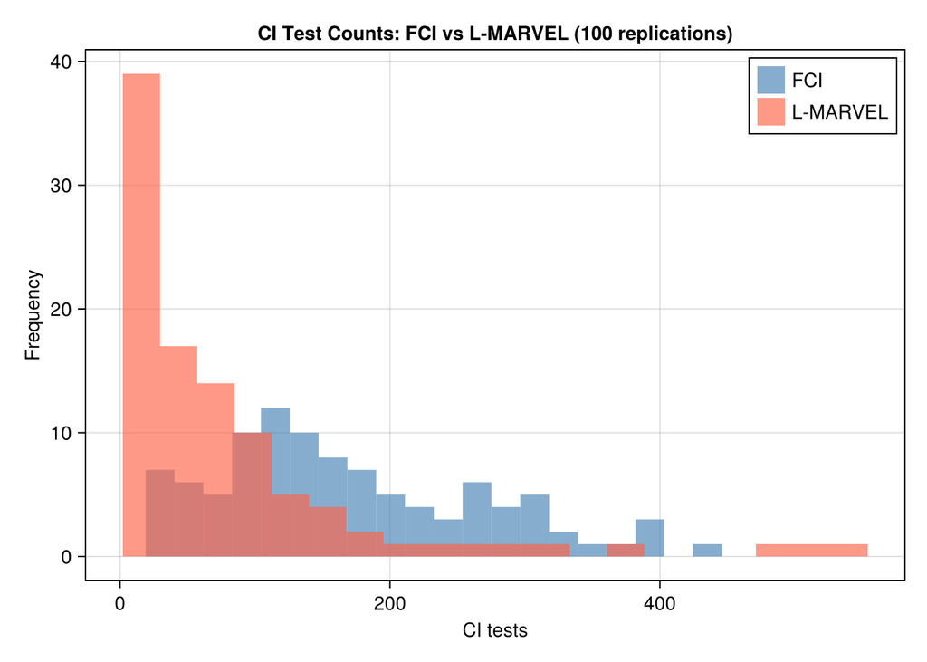

Figure 25.4: CI test count distributions across 100 replications.

```julia
let
    fig = Figure(size=(650, 380))
    ax  = Axis(fig[1,1];
        xlabel = "CI tests",
        ylabel = "Frequency",
        title  = "CI Test Counts: FCI vs L-MARVEL (100 replications)")
    hist!(ax, [r.ci_fci for r in mc]; bins=20, color=(:steelblue, 0.65), label="FCI")
    hist!(ax, [r.ci_lm  for r in mc]; bins=20, color=(:tomato, 0.65),    label="L-MARVEL")
    axislegend(ax)
    fig
end
```

## 25.7 Summary

| Property | PC / RSL-D | FCI | L-MARVEL |
| --- | --- | --- | --- |
| Latent confounders | No: assumes none | Yes | Yes |
| Output | CPDAG | PAG | Skeleton |
| Orientations | ✓ | ✓ | ✗ |
| MB estimation | CI tests | CI tests | Precision matrix |
| CI complexity | PC: $O(p^2 2^p)$ worst case; RSL-D: $O(p \cdot d \cdot \|\text{MB}\|^2)$ | Same as PC | Fewer (Gaussian MB pre-filters) |

FCI and L-MARVEL serve different purposes. Use FCI when orientations matter. Use L-MARVEL when the goal is a faster skeleton screen.

### 25.7.1 Practical decision guide

**Use PC or RSL-D when:** - You are confident in causal sufficiency (all relevant variables are measured) - You want a CPDAG that you can orient further with background knowledge - RSL-D is preferred over PC when $p > 10$ or the graph may be moderately dense

**Use FCI when:** - You suspect hidden confounders but don’t know where - You need edge orientations and $\leftrightarrow$ marks to guide IV or proxy strategies - Sample size is large enough that CI-test errors don’t cascade badly through orientation rules

**Use L-MARVEL when:** - You suspect latent confounders and have many variables ($p > 20$) - The goal is to prune the adjacency graph before applying domain knowledge or estimation - Gaussian data is appropriate (precision matrix estimator requires this)

### 25.7.2 From discovery to estimation

Causal discovery is a first step, not a final answer. A reasonable workflow is:

1. **Discover** — run FCI or L-MARVEL to get candidate adjacencies and, if using FCI, some edge marks
2. **Refine** — apply temporal ordering, institutional knowledge, and exclusion restrictions to orient remaining edges
3. **Identify** — check whether the effect of interest is identified given the refined graph (backdoor, front-door, ID algorithm)
4. **Estimate** — use TMLE, AIPW, or the estimators in earlier chapters

Causal discovery narrows the space of possible structures. Domain knowledge still does the hard work.

**Warning**

**Sample size requirements**

L-MARVEL’s Gaussian MB estimator requires $n > p + 1$ samples. With many variables and limited data, fall back to CI-test-based MB estimation by passing a custom `mb_estimator` to `l_marvel`.

**Note**

**Going further: orientation in the latent case**

FCI’s PAG output distinguishes definite causes ($\to$), definite hidden common causes ($\leftrightarrow$), and uncertain cases ($\circ$). The PAG can be combined with background knowledge such as temporal ordering to further orient edges before estimation.

## 25.8 How Much Does Causal Discovery Help in Economics?

Recovering the MAG skeleton is still far from recovering the full DAG. Much is still missing:

| What is recovered | What is still missing |
| --- | --- |
| L-MARVEL skeleton | Edge directions; direct cause vs. hidden common cause; latent nodes |
| FCI PAG | Unique MAG; latent nodes; most edges still carry $\circ$ marks |
| True MAG | Latent nodes and their connections |
| Full DAG | Nothing — this is the goal |

The core econometric question is almost always “what is the causal effect of $X$ on $Y$?” Causal discovery with latent variables does not answer this directly. A definite $X \leftrightarrow Y$ in a PAG tells you confounding exists — but not how to remove it. Without oriented edges you cannot even check whether the effect is identified, let alone estimate it.

**Where these methods do add value in economics:**

1. **Falsifying structural models.** If your model implies $X \perp\!\!\!\perp Z \mid W$, test it. A rejection means the model’s independence assumptions are inconsistent with the data — discovery tells you *which* assumptions fail before you commit to a full structural estimation.
2. **Flagging where instruments are needed.** A definite $X \leftrightarrow Y$ in the PAG is a data-driven diagnostic: OLS of $Y$ on $X$ is biased, and you need an instrument, proxy, or natural experiment. Discovery does not supply the instrument but tells you where to look for one.
3. **High-dimensional variable selection.** With many candidate controls, knowing which pairs are conditionally independent prunes the problem before applying identification strategies. This is most useful in settings with $p > 20$ variables where theory does not specify the full graph.
4. **Hypothesis generation when theory is silent.** For new economic phenomena — platform markets, fintech, peer effects in novel settings — where theory does not give a strong causal ordering, discovery algorithms generate hypotheses worth investigating with better-powered research designs.

Causal discovery is a complement to IV, RD, DiD, and synthetic control, not a substitute. It is most useful early in a project, as a diagnostic and hypothesis-generating tool.

Miao, Wang, Zhi Geng, and Eric J. Tchetgen Tchetgen. 2018. “Identifying Causal Effects with Proxy Variables of an Unmeasured Confounder.” *Biometrika* 105 (4): 987–93. https://doi.org/10.1093/biomet/asy038.

Mokhtarian, Ehsan, Sepehr Elahi, Sina Akbari, and Negar Kiyavash. 2025. “Recursive Causal Discovery.” *Journal of Machine Learning Research* 26: 1–65.

Tchetgen Tchetgen, Eric J., Andrew Ying, Yifan Cui, Xu Shi, and Wang Miao. 2024. “An Introduction to Proximal Causal Inference.” *Statistical Science* 39 (3): 375–90. https://doi.org/10.1214/23-STS911.